# README

# PRELIMINARY datasets for Seaglider ‘sg607’

Non-audio data from Seagliders was prepared using the Post-mission processing via [agate (Acoustic Glider Analysis Tools and Environment, v1.3.20260902)](https://sfregosi.github.io/agate/). Below are descriptions of the available datasets:

## sg607_20260128_flight_timeseries_engineering.csv

The flight engineering dataset contains information on the pitch, roll, heading, and vbdCC for each dive. Methods to develop this dataset can be found on the Agate instructions (https://sfregosi.github.io/agate/), and definitions/units for data are found in the table below. *Note: Data are preliminary and require additional QAQC.*

The two Seagliders have different CTDs (SG274 has an RBR Legato; SG607 has a Seabird); therefore, the flight data is available on two different time “scales” based on different sensor clocks. Measured engineering data is on the glider’s internal time schedule. Modeled flight data (speeds, displacement, buoyancy, etc. all are sampled at the times of the CTD data).

| Column_Name | Dataset | Definition | Units |
| --- | --- | --- | --- |
| dive | flight_timeseries_engineering | Dive number (sequential starting at 1) for a complete dive (a single ‘yo’). A dive begins when the glider submerges to begin a descent and ends when the glider surfaces at the end of an ascent. | numerical integer |
| time | flight_timeseries_engineering | Time (seconds since 1970-01-01T00:00:00+00:00) | seconds (s) |
| pitch | flight_timeseries_engineering | The angle between the gliders’s longitudinal centerline and the horizontal plane of the earth. A positive pitch represents a ‘nose-up’ attitude; a negative pitch respresents a ‘nose-down’ attitude. | degrees (°) |
| roll | flight_timeseries_engineering | The angular rotation of the glider around its’ longitudinal axis. A positive value is rolled to starboard (starboard wing down). | degrees (°) |
| heading | flight_timeseries_engineering | Measured heading (magnetic) | degrees (°) |
| vbdCC | flight_timeseries_engineering | Measurement of the glider’s variable buoyancy device (VBD; buoyancy engine) position relative to neutral. | cubic centimeters (cc) |

## sg607_20260128_flight_timeseries_modeled.csv

The modeled dataset contains information on the estimated glider speed (including vertical and horizontal speed), glider angle, buoyancy, and displacement (nort, east). Methods to develop this dataset can be found on the Agate instructions (https://sfregosi.github.io/agate/), and definitions/units for data are found in the table below. *Note: Data are preliminary and require additional QAQC.*

The two Seagliders have different CTDs (SG274 has an RBR Legato; SG607 has a Seabird); therefore, the flight data is available on two different time “scales” based on different sensor clocks. Measured engineering data is on the glider’s internal time schedule. Modeled flight data (speeds, displacement, buoyancy, etc. all are sampled at the times of the CTD data).

| Column_Name | Dataset | Definition | Units |
| --- | --- | --- | --- |
| dive | flight_timeseries_modeled | Dive number (sequential starting at 1) for a complete dive (a single ‘yo’). A dive begins when the glider submerges to begin a descent and ends when the glider surfaces at the end of an ascent. | numerical integer |
| time | flight_timeseries_modeled | Time (seconds since 1970-01-01T00:00:00+00:00) | seconds (s) |
| vertSpeed | flight_timeseries_modeled | The velocity along the vertical z-axis during the dive. Based on the hydrodynamic model. | centimeters per second (cm/s) |
| horzSpeed | flight_timeseries_modeled | The horizontal velocity through the water during the dive. Based on the hydrodynamic model. | centimeters per second (cm/s) |
| speed | flight_timeseries_modeled | Vehicle speed based on the hydrodynamic flight model. | centimeters per second (cm/s) |
| speed_qc | flight_timeseries_modeled | Flag to for quality of speed calculation. 0 - QC_NO_CHANGE 1 -QC_GOOD 2 - QC_PROBABLY_GOOD 3 - QC_PROBABLY_BAD 4 - QC_BAD 5 - QC_CHANGED 6 - QC_UNSAMPLED 8 - QC_INTERPOLATED 9 - QC_MISSING | n/a |
| glideAngle | flight_timeseries_modeled | The downward or upward slope angle at which the vehicle moves through the water relative to the horizontal plane, based on the hydrodynamic model. | degrees (°) |
| buoyancy | flight_timeseries_modeled | Buoyancy of vehicle, corrected for compression effects, based on the hydrodynamic model. | grams (g) |
| north_displacement | flight_timeseries_modeled | The estimated distance (in meters) the glider has traveled northward during the dive, based on the hydrodynamic model. | meters (m) |
| east_displacement | flight_timeseries_modeled | The estimated distance (in meters) the glider has traveled eastward during the dive, based on the hydrodynamic model. | meters (m) |

## sg607_20260128_GPS_timeseries.csv

GPS time series data is formatted with one row per dive, with start and end times and locations for each dive. Movement between the end of one dive and the start of the next is due to any surface drift. The GPS dataset contains information on the Start and End Time, Latitude, Longitude as well as the duration, distance, and max depth for each dive. Additional variables are presented in the table (below). Methods to develop this dataset can be found on the Agate instructions (https://sfregosi.github.io/agate/), and definitions/units for data are found in the table below. *Note: Data are preliminary and require additional QAQC.*

[output not shown]

** Quality flags for validity of data dependent on hydrodynamic model (valude hdm_qc):

- “Whether corrected temperatures, salinities, and velocities from the hydrodynamic model converged on a consistent solution”
- flag_values: “0 1 2 3 4 5 6 8 9”
- flag_meanings: “QC_NO_CHANGE QC_GOOD QC_PROBABLY_GOOD QC_PROBABLY_BAD QC_BAD QC_CHANGED QC_UNSAMPLED QC_INTERPOLATED QC_MISSING”

## sg607_20260128_science_timeseries.csv

The science dataset contains information on the depth, temperature, salinity, density, and sound velocity for each dive. Methods to develop this dataset can be found on the Agate instructions (https://sfregosi.github.io/agate/), and definitions/units for data are found in the table below. *Note: Data are preliminary and require additional QAQC.*

| Column_Name | Dataset | Definition | Units |
| --- | --- | --- | --- |
| dive | science_timeseries | Dive number (sequential starting at 1) for a complete dive (a single ‘yo’). A dive begins when the glider submerges to begin a descent and ends when the glider surfaces at the end of an ascent. | numerical integer |
| time | science_timeseries | Time (seconds since 1970-01-01T00:00:00+00:00) | seconds (s) |
| latitude | science_timeseries | Latitude in decimal degrees (DD.DDDD), estimated from the hydrodynamic model. | decimal degrees |
| longitude | science_timeseries | Longitude in decimal degrees (DD.DDDD), estimated from the hydrodynamic model. | decimal degrees |
| depth | science_timeseries | Depth in meters | meters (m) |
| temperature | science_timeseries | Temperature (in situ). | celcius degrees (°C) |
| salinity | science_timeseries | Salinity, corrected for thermal-intertia effects. | Practical Salinity Units (PSU) |
| density | science_timeseries | Seawater potential density. | kilograms/cubic meter (kg m-3) |
| soundVelocity | science_timeseries | Underwater sound velocity. Calculated using the Gibbs Seawater Toolbox (GSW) ‘gsw_sound_speed’ equation. | meters per second (m/s) |

## sg607_20260128_WHICEAS_SSP.png

Soundspeed profile for the WHICEAS mission (which includes the Glider Rodeo).

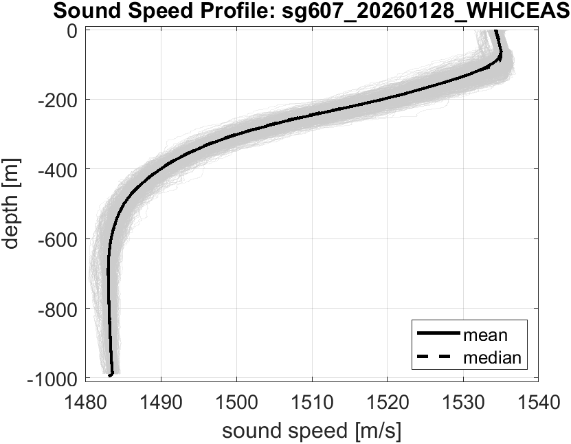

## sg607_20260128_FakeData_EventDetections.csv

Due to complications beyond our control, accurate acoustic detection of cetacean species via manual and/or automated methods could not be completed prior to the Hackathon. A set of synthesized (fake!) data was provided in the data/detection folder to provide sample formatted data if a group would like to lead a project working with marine mammal acoustic data (projects developed with these synthesized datasets should be reproducible with real datasets in the future!). Field definitions/units for data are found in the table below (fields are the same for EventDetections and HrlyDetections).

## sg607_20260128_FakeData_HrlyDetections.csv

Hourly Detections (ex, FakeData_HrlyDetections_GliderRodeo2026_Belladonna.csv) These files show positive detections in hourly bins. Effort with no detections are not provided.

[output not shown]